# Part I - (ProsperLoanData)

## by (Edeh, Chinonso James)

- Introduction
- Preliminary Wrangling
- Univariate Exploration
- Bivariate Exploration
- Multivariate Exploration
- Conclusion

## Introduction

This dataset contains 113,937 loans with 81 variables on each loan, including loan amount, borrower rate (or interest rate), curent loan status, borrower income, and many others.

## Preliminary Wrangling

```python
# import all packages and set plots to be embedded inline
import numpy as np
import pandas as pd
import matplotlib.pyplot as plt
import seaborn as sb

%matplotlib inline
```

```python
# load in the dataset into a pandas dataframe
df = pd.read_csv('prosperLoanData.csv')
```

```python
df.head(5)
```

|  | ListingKey | ListingNumber | ListingCreationDate | CreditGrade | Term | LoanStatus | ClosedDate | BorrowerAPR | BorrowerRate | LenderYield | ... | LP_ServiceFees | LP_CollectionFees | LP_GrossPrincipalLoss | LP_NetPrincipalLoss | LP_NonPrincipalRecoverypayments | PercentFunded | Recommendations | InvestmentFromFriendsCount | InvestmentFromFriendsAmount | Investors |
| --- | --- | --- | --- | --- | --- | --- | --- | --- | --- | --- | --- | --- | --- | --- | --- | --- | --- | --- | --- | --- | --- |
| 0 | 1021339766868145413AB3B | 193129 | 2007-08-26 19:09:29.263000000 | C | 36 | Completed | 2009-08-14 00:00:00 | 0.16516 | 0.1580 | 0.1380 | ... | -133.18 | 0.0 | 0.0 | 0.0 | 0.0 | 1.0 | 0 | 0 | 0.0 | 258 |
| 1 | 10273602499503308B223C1 | 1209647 | 2014-02-27 08:28:07.900000000 | NaN | 36 | Current | NaN | 0.12016 | 0.0920 | 0.0820 | ... | 0.00 | 0.0 | 0.0 | 0.0 | 0.0 | 1.0 | 0 | 0 | 0.0 | 1 |
| 2 | 0EE9337825851032864889A | 81716 | 2007-01-05 15:00:47.090000000 | HR | 36 | Completed | 2009-12-17 00:00:00 | 0.28269 | 0.2750 | 0.2400 | ... | -24.20 | 0.0 | 0.0 | 0.0 | 0.0 | 1.0 | 0 | 0 | 0.0 | 41 |
| 3 | 0EF5356002482715299901A | 658116 | 2012-10-22 11:02:35.010000000 | NaN | 36 | Current | NaN | 0.12528 | 0.0974 | 0.0874 | ... | -108.01 | 0.0 | 0.0 | 0.0 | 0.0 | 1.0 | 0 | 0 | 0.0 | 158 |
| 4 | 0F023589499656230C5E3E2 | 909464 | 2013-09-14 18:38:39.097000000 | NaN | 36 | Current | NaN | 0.24614 | 0.2085 | 0.1985 | ... | -60.27 | 0.0 | 0.0 | 0.0 | 0.0 | 1.0 | 0 | 0 | 0.0 | 20 |

5 rows × 81 columns

```python
df.info()
```

```
<class 'pandas.core.frame.DataFrame'>
RangeIndex: 113937 entries, 0 to 113936
Data columns (total 81 columns):
 #   Column                               Non-Null Count   Dtype
---  ------                               --------------   -----
 0   ListingKey                           113937 non-null  object
 1   ListingNumber                        113937 non-null  int64
 2   ListingCreationDate                  113937 non-null  object
 3   CreditGrade                          28953 non-null   object
 4   Term                                 113937 non-null  int64
 5   LoanStatus                           113937 non-null  object
 6   ClosedDate                           55089 non-null   object
 7   BorrowerAPR                          113912 non-null  float64
 8   BorrowerRate                         113937 non-null  float64
 9   LenderYield                          113937 non-null  float64
```

[output cut: 73 more lines]

```python
#descriptive statistics for numeric variables
df.describe()
```

|  | ListingNumber | Term | BorrowerAPR | BorrowerRate | LenderYield | EstimatedEffectiveYield | EstimatedLoss | EstimatedReturn | ProsperRating (numeric) | ProsperScore | ... | LP_ServiceFees | LP_CollectionFees | LP_GrossPrincipalLoss | LP_NetPrincipalLoss | LP_NonPrincipalRecoverypayments | PercentFunded | Recommendations | InvestmentFromFriendsCount | InvestmentFromFriendsAmount | Investors |
| --- | --- | --- | --- | --- | --- | --- | --- | --- | --- | --- | --- | --- | --- | --- | --- | --- | --- | --- | --- | --- | --- |
| count | 1.139370e+05 | 113937.000000 | 113912.000000 | 113937.000000 | 113937.000000 | 84853.000000 | 84853.000000 | 84853.000000 | 84853.000000 | 84853.000000 | ... | 113937.000000 | 113937.000000 | 113937.000000 | 113937.000000 | 113937.000000 | 113937.000000 | 113937.000000 | 113937.000000 | 113937.000000 | 113937.000000 |
| mean | 6.278857e+05 | 40.830248 | 0.218828 | 0.192764 | 0.182701 | 0.168661 | 0.080306 | 0.096068 | 4.072243 | 5.950067 | ... | -54.725641 | -14.242698 | 700.446342 | 681.420499 | 25.142686 | 0.998584 | 0.048027 | 0.023460 | 16.550751 | 80.475228 |
| std | 3.280762e+05 | 10.436212 | 0.080364 | 0.074818 | 0.074516 | 0.068467 | 0.046764 | 0.030403 | 1.673227 | 2.376501 | ... | 60.675425 | 109.232758 | 2388.513831 | 2357.167068 | 275.657937 | 0.017919 | 0.332353 | 0.232412 | 294.545422 | 103.239020 |
| min | 4.000000e+00 | 12.000000 | 0.006530 | 0.000000 | -0.010000 | -0.182700 | 0.004900 | -0.182700 | 1.000000 | 1.000000 | ... | -664.870000 | -9274.750000 | -94.200000 | -954.550000 | 0.000000 | 0.700000 | 0.000000 | 0.000000 | 0.000000 | 1.000000 |
| 25% | 4.009190e+05 | 36.000000 | 0.156290 | 0.134000 | 0.124200 | 0.115670 | 0.042400 | 0.074080 | 3.000000 | 4.000000 | ... | -73.180000 | 0.000000 | 0.000000 | 0.000000 | 0.000000 | 1.000000 | 0.000000 | 0.000000 | 0.000000 | 2.000000 |
| 50% | 6.005540e+05 | 36.000000 | 0.209760 | 0.184000 | 0.173000 | 0.161500 | 0.072400 | 0.091700 | 4.000000 | 6.000000 | ... | -34.440000 | 0.000000 | 0.000000 | 0.000000 | 0.000000 | 1.000000 | 0.000000 | 0.000000 | 0.000000 | 44.000000 |
| 75% | 8.926340e+05 | 36.000000 | 0.283810 | 0.250000 | 0.240000 | 0.224300 | 0.112000 | 0.116600 | 5.000000 | 8.000000 | ... | -13.920000 | 0.000000 | 0.000000 | 0.000000 | 0.000000 | 1.000000 | 0.000000 | 0.000000 | 0.000000 | 115.000000 |
| max | 1.255725e+06 | 60.000000 | 0.512290 | 0.497500 | 0.492500 | 0.319900 | 0.366000 | 0.283700 | 7.000000 | 11.000000 | ... | 32.060000 | 0.000000 | 25000.000000 | 25000.000000 | 21117.900000 | 1.012500 | 39.000000 | 33.000000 | 25000.000000 | 1189.000000 |

8 rows × 61 columns

```python
df.isnull().sum()
```

```
ListingKey                         0
ListingNumber                      0
ListingCreationDate                0
CreditGrade                    84984
Term                               0
                               ...
PercentFunded                      0
Recommendations                    0
InvestmentFromFriendsCount         0
InvestmentFromFriendsAmount        0
Investors                          0
Length: 81, dtype: int64
```

### What is the structure of your dataset?

> There are 113,937 loans records with 81 columns. Most of the variables are numeric in nature; mostly float64 datatypes (50), int64(11), object(17) and bool(3). There are some missing data on some variables, and not all variables will be significant for my analysis.

### What is/are the main feature(s) of interest in your dataset?

> What factors affect a loan's outcome status?

> Are there differences between loans depending on how large the original loan amount was?

### What features in the dataset do you think will help support your investigation into your feature(s) of interest?

> I expect the LoanStatus to be the strongest variable that will support my investigation in determing factors that affect outcome of loan status.

> I also think LoanOriginalAmount will play an important role in supporting my investigation for analyzing differences between loans.

### Data Assessing and Cleaning

REMOVING UNNECESSARY COLUMNS

```python
loan = ["ListingKey","ListingCreationDate", "Term", "LoanStatus", "BorrowerState", "Occupation",
        "EmploymentStatus", "EmploymentStatusDuration", "IsBorrowerHomeowner",
        "IncomeRange", "IncomeVerifiable", "StatedMonthlyIncome", "LoanOriginalAmount",
        "LoanOriginationDate", "MonthlyLoanPayment", "Recommendations"]
```

```python
loans = df[loan]
```

```python
loans.head(5)
```

|  | ListingKey | ListingCreationDate | Term | LoanStatus | BorrowerState | Occupation | EmploymentStatus | EmploymentStatusDuration | IsBorrowerHomeowner | IncomeRange | IncomeVerifiable | StatedMonthlyIncome | LoanOriginalAmount | LoanOriginationDate | MonthlyLoanPayment | Recommendations |
| --- | --- | --- | --- | --- | --- | --- | --- | --- | --- | --- | --- | --- | --- | --- | --- | --- |
| 0 | 1021339766868145413AB3B | 2007-08-26 19:09:29.263000000 | 36 | Completed | CO | Other | Self-employed | 2.0 | True | $25,000-49,999 | True | 3083.333333 | 9425 | 2007-09-12 00:00:00 | 330.43 | 0 |
| 1 | 10273602499503308B223C1 | 2014-02-27 08:28:07.900000000 | 36 | Current | CO | Professional | Employed | 44.0 | False | $50,000-74,999 | True | 6125.000000 | 10000 | 2014-03-03 00:00:00 | 318.93 | 0 |
| 2 | 0EE9337825851032864889A | 2007-01-05 15:00:47.090000000 | 36 | Completed | GA | Other | Not available | NaN | False | Not displayed | True | 2083.333333 | 3001 | 2007-01-17 00:00:00 | 123.32 | 0 |
| 3 | 0EF5356002482715299901A | 2012-10-22 11:02:35.010000000 | 36 | Current | GA | Skilled Labor | Employed | 113.0 | True | $25,000-49,999 | True | 2875.000000 | 10000 | 2012-11-01 00:00:00 | 321.45 | 0 |
| 4 | 0F023589499656230C5E3E2 | 2013-09-14 18:38:39.097000000 | 36 | Current | MN | Executive | Employed | 44.0 | True | $100,000+ | True | 9583.333333 | 15000 | 2013-09-20 00:00:00 | 563.97 | 0 |

```python
loans.info()
```

```
<class 'pandas.core.frame.DataFrame'>
RangeIndex: 113937 entries, 0 to 113936
Data columns (total 16 columns):
 #   Column                    Non-Null Count   Dtype
---  ------                    --------------   -----
 0   ListingKey                113937 non-null  object
 1   ListingCreationDate       113937 non-null  object
 2   Term                      113937 non-null  int64
 3   LoanStatus                113937 non-null  object
 4   BorrowerState             108422 non-null  object
 5   Occupation                110349 non-null  object
 6   EmploymentStatus          111682 non-null  object
 7   EmploymentStatusDuration  106312 non-null  float64
 8   IsBorrowerHomeowner       113937 non-null  bool
 9   IncomeRange               113937 non-null  object
 10  IncomeVerifiable          113937 non-null  bool
 11  StatedMonthlyIncome       113937 non-null  float64
 12  LoanOriginalAmount        113937 non-null  int64
 13  LoanOriginationDate       113937 non-null  object
 14  MonthlyLoanPayment        113937 non-null  float64
 15  Recommendations           113937 non-null  int64
dtypes: bool(2), float64(3), int64(3), object(8)
memory usage: 12.4+ MB
```

```python
loans.duplicated().sum()
```

```
871
```

###### DROP NULL ROWS

```python
loans.dropna(axis = 0, inplace = True)
```

###### REMOVE DUPLICATES

```python
loans.drop_duplicates(inplace = True)
```

```python
loans.info()
```

```
<class 'pandas.core.frame.DataFrame'>
Int64Index: 102433 entries, 0 to 113936
Data columns (total 16 columns):
 #   Column                    Non-Null Count   Dtype
---  ------                    --------------   -----
 0   ListingKey                102433 non-null  object
 1   ListingCreationDate       102433 non-null  object
 2   Term                      102433 non-null  int64
 3   LoanStatus                102433 non-null  object
 4   BorrowerState             102433 non-null  object
 5   Occupation                102433 non-null  object
 6   EmploymentStatus          102433 non-null  object
 7   EmploymentStatusDuration  102433 non-null  float64
 8   IsBorrowerHomeowner       102433 non-null  bool
 9   IncomeRange               102433 non-null  object
 10  IncomeVerifiable          102433 non-null  bool
 11  StatedMonthlyIncome       102433 non-null  float64
 12  LoanOriginalAmount        102433 non-null  int64
 13  LoanOriginationDate       102433 non-null  object
 14  MonthlyLoanPayment        102433 non-null  float64
 15  Recommendations           102433 non-null  int64
dtypes: bool(2), float64(3), int64(3), object(8)
memory usage: 11.9+ MB
```

```python
loans.describe()
```

|  | Term | EmploymentStatusDuration | StatedMonthlyIncome | LoanOriginalAmount | MonthlyLoanPayment | Recommendations |
| --- | --- | --- | --- | --- | --- | --- |
| count | 102433.000000 | 102433.000000 | 1.024330e+05 | 102433.000000 | 102433.000000 | 102433.000000 |
| mean | 41.240811 | 96.923013 | 5.711332e+03 | 8587.660295 | 279.585859 | 0.050228 |
| std | 10.791948 | 93.917154 | 7.708061e+03 | 6275.811252 | 192.155261 | 0.342737 |
| min | 12.000000 | 0.000000 | 0.000000e+00 | 1000.000000 | 0.000000 | 0.000000 |
| 25% | 36.000000 | 27.000000 | 3.333333e+03 | 4000.000000 | 139.350000 | 0.000000 |
| 50% | 36.000000 | 68.000000 | 4.830333e+03 | 7000.000000 | 230.360000 | 0.000000 |
| 75% | 36.000000 | 138.000000 | 6.963917e+03 | 12000.000000 | 378.050000 | 0.000000 |
| max | 60.000000 | 755.000000 | 1.750003e+06 | 35000.000000 | 2251.510000 | 39.000000 |

```python
loans.sort_values(by = 'StatedMonthlyIncome', ascending = False)
```

|  | ListingKey | ListingCreationDate | Term | LoanStatus | BorrowerState | Occupation | EmploymentStatus | EmploymentStatusDuration | IsBorrowerHomeowner | IncomeRange | IncomeVerifiable | StatedMonthlyIncome | LoanOriginalAmount | LoanOriginationDate | MonthlyLoanPayment | Recommendations |
| --- | --- | --- | --- | --- | --- | --- | --- | --- | --- | --- | --- | --- | --- | --- | --- | --- |
| 53167 | F9AD3540233111834F3D8A0 | 2012-02-20 12:53:44.577000000 | 36 | Current | OR | Professional | Self-employed | 114.0 | True | $100,000+ | False | 1.750003e+06 | 4000 | 2012-02-24 00:00:00 | 173.71 | 0 |
| 53014 | F5D13567265432980C80C7D | 2013-01-04 20:02:24.207000000 | 12 | Completed | CA | Other | Self-employed | 117.0 | True | $100,000+ | False | 6.185478e+05 | 4000 | 2013-01-23 00:00:00 | 366.62 | 0 |
| 17411 | 873B351262140884511D81C | 2011-04-08 21:58:21.847000000 | 36 | Completed | HI | Professional | Employed | 121.0 | True | $100,000+ | True | 4.833333e+05 | 7500 | 2011-05-06 00:00:00 | 326.62 | 0 |
| 57133 | BF643510331462185E12917 | 2011-03-24 14:50:00.220000000 | 36 | Current | CT | Other | Employed | 271.0 | True | $100,000+ | True | 4.666667e+05 | 4000 | 2011-04-05 00:00:00 | 174.20 | 0 |
| 8066 | 37043512916744588463B5A | 2011-04-02 13:58:32.227000000 | 36 | Completed | IL | Police Officer/Correction Officer | Employed | 183.0 | True | $100,000+ | True | 4.166667e+05 | 2000 | 2011-04-26 00:00:00 | 87.10 | 0 |
| ... | ... | ... | ... | ... | ... | ... | ... | ... | ... | ... | ... | ... | ... | ... | ... | ... |
| 40439 | 131C35173624950888E9710 | 2011-06-03 14:08:16.323000000 | 36 | Completed | NY | Other | Not employed | 15.0 | False | Not employed | False | 0.000000e+00 | 3093 | 2011-06-23 00:00:00 | 134.68 | 0 |
| 77776 | FE2F3399584837261B59B4C | 2007-09-14 12:52:43.347000000 | 36 | Completed | MI | Construction | Full-time | 139.0 | False | $0 | False | 0.000000e+00 | 1200 | 2007-09-20 00:00:00 | 33.59 | 0 |
| 40432 | 4D763527175683761E1B876 | 2011-09-23 14:33:42.830000000 | 36 | Completed | NY | Other | Not employed | 96.0 | False | Not employed | False | 0.000000e+00 | 4200 | 2011-09-28 00:00:00 | 171.44 | 0 |
| 5535 | 31E035529807292013B8608 | 2012-07-17 06:29:03.920000000 | 36 | Current | NJ | Other | Not employed | 1.0 | False | Not employed | False | 0.000000e+00 | 2000 | 2012-07-23 00:00:00 | 75.34 | 0 |
| 90118 | 9CB03510382839826534495 | 2011-03-15 08:31:16.057000000 | 60 | Completed | IL | Other | Not employed | 2.0 | True | Not employed | False | 0.000000e+00 | 7765 | 2011-03-31 00:00:00 | 216.63 | 0 |

102433 rows × 16 columns

###### REMOVE OUTLIER

An outlier in StatedMonthlyIncome column of 1750002.916667. Replace this value with 175002.916667

```python
loans['StatedMonthlyIncome'].replace(1750002.916667, 175002.916667, inplace = True)
```

```python
loans.sort_values(by = 'StatedMonthlyIncome', ascending = False)
```

|  | ListingKey | ListingCreationDate | Term | LoanStatus | BorrowerState | Occupation | EmploymentStatus | EmploymentStatusDuration | IsBorrowerHomeowner | IncomeRange | IncomeVerifiable | StatedMonthlyIncome | LoanOriginalAmount | LoanOriginationDate | MonthlyLoanPayment | Recommendations |
| --- | --- | --- | --- | --- | --- | --- | --- | --- | --- | --- | --- | --- | --- | --- | --- | --- |
| 53014 | F5D13567265432980C80C7D | 2013-01-04 20:02:24.207000000 | 12 | Completed | CA | Other | Self-employed | 117.0 | True | $100,000+ | False | 618547.833333 | 4000 | 2013-01-23 00:00:00 | 366.62 | 0 |
| 17411 | 873B351262140884511D81C | 2011-04-08 21:58:21.847000000 | 36 | Completed | HI | Professional | Employed | 121.0 | True | $100,000+ | True | 483333.333333 | 7500 | 2011-05-06 00:00:00 | 326.62 | 0 |
| 57133 | BF643510331462185E12917 | 2011-03-24 14:50:00.220000000 | 36 | Current | CT | Other | Employed | 271.0 | True | $100,000+ | True | 466666.666667 | 4000 | 2011-04-05 00:00:00 | 174.20 | 0 |
| 8066 | 37043512916744588463B5A | 2011-04-02 13:58:32.227000000 | 36 | Completed | IL | Police Officer/Correction Officer | Employed | 183.0 | True | $100,000+ | True | 416666.666667 | 2000 | 2011-04-26 00:00:00 | 87.10 | 0 |
| 113270 | D3AF357238727540198D36B | 2013-02-20 19:23:37.430000000 | 36 | Current | CA | Other | Employed | 173.0 | False | $100,000+ | True | 394400.000000 | 2000 | 2013-02-26 00:00:00 | 73.30 | 0 |
| ... | ... | ... | ... | ... | ... | ... | ... | ... | ... | ... | ... | ... | ... | ... | ... | ... |
| 40439 | 131C35173624950888E9710 | 2011-06-03 14:08:16.323000000 | 36 | Completed | NY | Other | Not employed | 15.0 | False | Not employed | False | 0.000000 | 3093 | 2011-06-23 00:00:00 | 134.68 | 0 |
| 77776 | FE2F3399584837261B59B4C | 2007-09-14 12:52:43.347000000 | 36 | Completed | MI | Construction | Full-time | 139.0 | False | $0 | False | 0.000000 | 1200 | 2007-09-20 00:00:00 | 33.59 | 0 |
| 40432 | 4D763527175683761E1B876 | 2011-09-23 14:33:42.830000000 | 36 | Completed | NY | Other | Not employed | 96.0 | False | Not employed | False | 0.000000 | 4200 | 2011-09-28 00:00:00 | 171.44 | 0 |
| 5535 | 31E035529807292013B8608 | 2012-07-17 06:29:03.920000000 | 36 | Current | NJ | Other | Not employed | 1.0 | False | Not employed | False | 0.000000 | 2000 | 2012-07-23 00:00:00 | 75.34 | 0 |
| 90118 | 9CB03510382839826534495 | 2011-03-15 08:31:16.057000000 | 60 | Completed | IL | Other | Not employed | 2.0 | True | Not employed | False | 0.000000 | 7765 | 2011-03-31 00:00:00 | 216.63 | 0 |

102433 rows × 16 columns

```python
loans.shape
```

```
(102433, 16)
```

```python
loans = loans.copy()
```

## Univariate Exploration

#### Distribution for the StatedMonthlyIncome variable

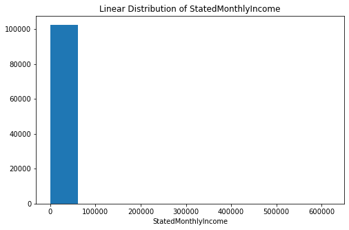

```python
# starting with a standard-scaled plot

plt.figure(figsize = [8,5])
plt.hist(data = loans, x = 'StatedMonthlyIncome')
plt.title('Linear Distribution of StatedMonthlyIncome')
plt.xlabel('StatedMonthlyIncome')
```

the standard scale could not show low value distributions, so let's put it on a log scale instead

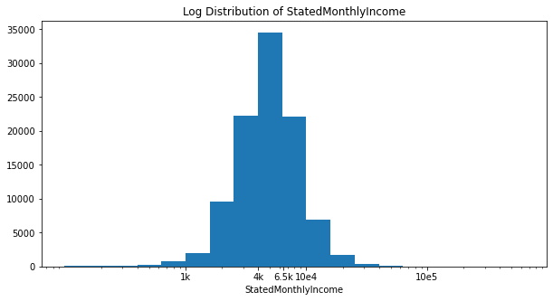

```python
# plotting on a linear scale
plt.figure(figsize = [10,5])
log_binsize = 0.2
bins = 10 ** np.arange(2, np.log10(loans['StatedMonthlyIncome'].max())+log_binsize, log_binsize)
plt.hist(data = loans, x = 'StatedMonthlyIncome', bins = bins)
plt.xscale('log')
plt.xticks([1000, 4000, 6500, 10000, 100000], ['1k', '4k', '6.5k', '10e4', '10e5'])
plt.title('Log Distribution of StatedMonthlyIncome')
plt.xlabel('StatedMonthlyIncome')
```

The linear scale for the StatedMonthlyIncome could not capture the distributions for low values. When plotted on a log scale, the StatedMonthlyIncome shows a normal distribution, with the peak values ranging from 4000 to 6500. As the value ranges above 6500, the plot slopes, indicating a decrease.

#### Distribution for the LoanOriginalAmount variable

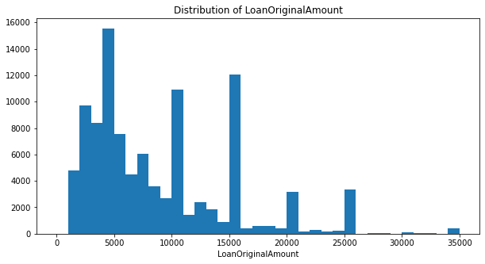

```python
plt.figure(figsize = [10,5])
bins = np.arange(0, loans['LoanOriginalAmount'].max()+1000, 1000)
plt.hist(data = loans, x = 'LoanOriginalAmount', bins = bins);
plt.title('Distribution of LoanOriginalAmount')
plt.xlabel('LoanOriginalAmount')
```

The distribution has several peak points. These points indicates the rise and fall of counts for the variable, with 4000 having the highest peak. Followed by 15000, 10000, 2000.

Ordering categorical variables

```python
term_order = sorted(loans['Term'].unique())
income_order=[ 'Not employed', '$0', '$1-24,999', '$25,000-49,999', '$50,000-74,999', '$75,000-99,999',
              '$100,000+', 'Not displayed']
status_order=[ 'Completed', 'Current', 'FinalPaymentInProgress', 'Past Due', 'Chardedoff', 'Defaulted', 'Cancelled']
employ_order=['Full-time', 'Self-employed', 'Employed', 'Part-time', 'Retired', 'Other', 'Not employed']
```

##### Defining functions for chart plots

```python
def countplot(data, x = 'x', order = ''):
    plt.figure(figsize = [20,6])
    base_color = sb.color_palette()[0]
    return sb.countplot(data = data, x = x, color = base_color, order = order)


def countplot_sub(data, x = 'x', order = 'order'):
    base_color = sb.color_palette()[0]
    return sb.countplot(data = data, x = x, color = base_color, order = order)
```

#### Distribution for the EmploymentStatus variable

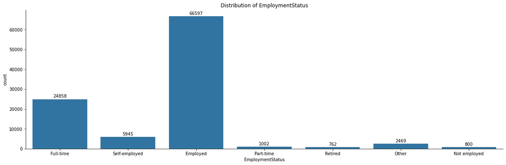

```python
countplot(loans, 'EmploymentStatus', employ_order)
plt.title('Distribution of EmploymentStatus')

type_counts = loans.EmploymentStatus.value_counts().reindex(employ_order)
for i in range(type_counts.shape[0]):
        c = type_counts[i]
        plt.text(i, c+1500, c, va ='center', ha = 'center', fontsize = 10)
#remove spine
sb.despine();
```

The bar chart above shows the distribution of the EmploymentStatus variable. The number of Employed borrowers is the highest, followed by the full-time, self-employed (66597, 24858, 5945 respectively). The Not employed and Retired have the least counts of borrowers with a count of 800 and 762 respectively.

#### Distribution for the BorrowerState variable

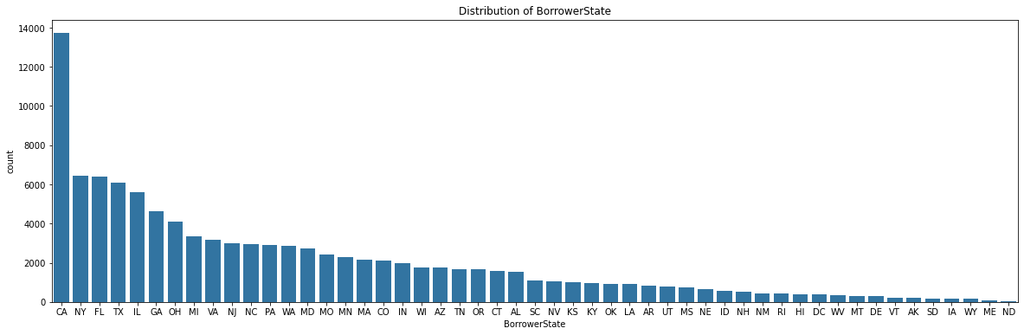

```python
countplot(loans, 'BorrowerState', order = order)
plt.title('Distribution of BorrowerState');
```

This plot shows that the state represented as CA has the highest number of borrowers.

#### Distribution for the LoanStatus variable

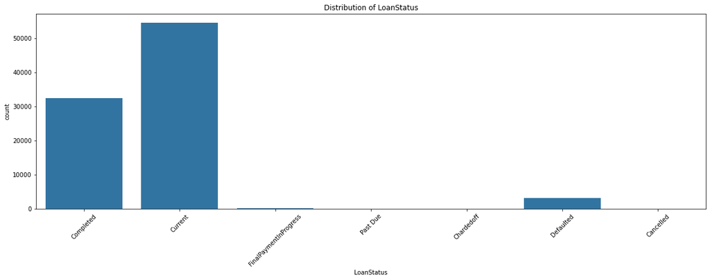

```python
countplot(loans, 'LoanStatus', status_order)
plt.xlabel('LoanStatus')
plt.title('Distribution of LoanStatus');
```

The bar chart above shows the distribution for the LoanStatus of the borrowers. There are more number of people with a current LoanStatus, followed by completed LoanStatus. There are least number of borrowers with cancelled LoanStatus

In order to determine the factors that affect a loan's outcome status, I will create a different datasets where the LoanStatus variable are of each 'Current', 'Completed', 'Chargedoff', 'Defaulted', also I will look into the 'Cancelled' Status.

```python
current = loans[loans['LoanStatus'] == 'Current']
completed = loans[loans['LoanStatus'] == 'Completed']
chargedoff = loans[loans['LoanStatus'] == 'Chargedoff']
defaulted = loans[loans['LoanStatus'] == 'Defaulted']
cancelled = loans[loans['LoanStatus'] == 'Cancelled']
```

#### Definition of functions for sub_plot charts

```python
# function to plot sub_plots for the different datasets to some variables
def sub_plot(df):
    plt.figure(figsize = [20,5])

    plt.subplot(1,5,1)
    countplot_sub(df, 'EmploymentStatus',  order = employ_order)
    plt.xticks(rotation = 90)

    plt.subplot(1,5,2)
    countplot_sub(df, 'Term', order = term_order)

    plt.subplot(1,5,3)
    countplot_sub(df, 'IncomeRange', order = income_order)
    plt.xticks(rotation = 90)

    plt.subplot(1,5,4)
    countplot_sub(df, 'IsBorrowerHomeowner', order = None)

    plt.subplot(1,5,5)
    return countplot_sub(df, 'IncomeVerifiable', order = None)
```

#### To investigate the features Associated with the Completed LoanStatus

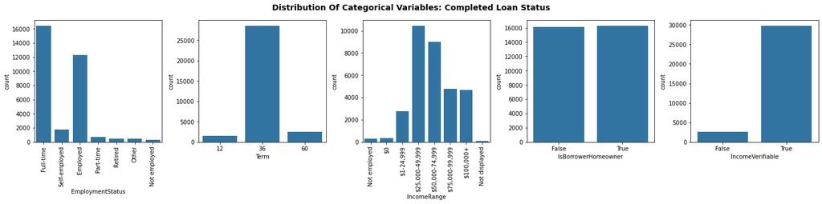

```python
sub_plot(completed)
plt.suptitle('Distribution of Categorical Variables: Completed Loan Status'.title(), fontsize =14, weight = 'bold')
plt.tight_layout()
```

The chart above is a subplots of variables for the completed LoanStatus dataset.

> The EmploymentStatus subplot shows that there are more number of borrowers with 'Full-time' and 'Employed' EmployedStatus. There is significant low value for the other status with 'Not employed' being the least of all.

> The 'Term' subplot shows that the number of borrowers that took 36 term is way more higher than the rest 60 and 12 terms

> IncomeRange of 25,000-49,999 has the highest counts of borrower, followed by 50,000 - 74,9999

> There is a close value of True/False for counts of 'IsBorrowerHomeowner

> More number of borrowers have their Income verified.

#### To investigate the features Associated with the Current LoanStatus

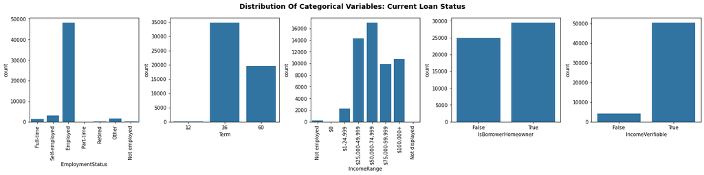

```python
sub_plot(current)
plt.suptitle('Distribution of Categorical Variables: Current Loan Status'.title(), fontsize =14, weight = 'bold')
plt.tight_layout()
```

The chart above is a subplots of variables for the Current LoanStatus dataset.

> The EmploymentStatus subplot shows that there are more number of borrowers with 'Employed' EmployedStatus. There is significant low value for the other status with 'Part-timed' being the least of all.

> The 'Term' subplot shows that the number of borrowers that took 36 term has higher value than the 60 Term. Very low value took 12 Term.

> IncomeRange of 50,000-74,999 has the highest counts of borrower, followed by 25,000 - 49,9999

> There are more borrowers that are Homeowner.

> More number of borrowers have their Income verified.

#### To investigate the features Associated with the Chargedoff LoanStatus

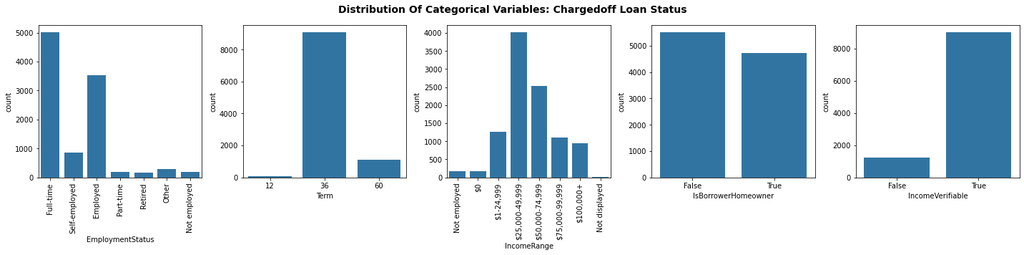

```python
sub_plot(chargedoff)
plt.suptitle('Distribution of Categorical Variables: Chargedoff Loan Status'.title(), fontsize =14, weight = 'bold')
plt.tight_layout()
```

The chart above is a subplots of variables for the Chargedoff LoanStatus dataset.

> The EmploymentStatus subplot shows that there are more number of borrowers with 'Full-time' and 'Employed' EmployedStatus. There is significant low value for the other status with 'Retired' being the least of all.

> The 'Term' subplot shows that the number of borrowers that took 36 term is way more higher than the rest 60 and 12 terms

> IncomeRange of 25,000-49,999 has the highest counts of borrower, followed by 50,000 - 74,9999

> More number of borrowers have their Income verified.

#### To investigate the features Associated with the Defaulted LoanStatus

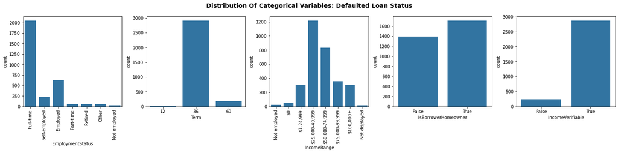

```python
sub_plot(defaulted)
plt.suptitle('Distribution of Categorical Variables: Defaulted Loan Status'.title(), fontsize =14, weight = 'bold')
plt.tight_layout()
```

The chart above is a subplots of variables for the Defaulted LoanStatus dataset.

> The EmploymentStatus subplot shows that there are more number of borrowers with 'Full-time' EmployedStatus. There is significant low value for the other status with 'Not employed' being the least of all.

> The 'Term' subplot shows that the number of borrowers that took 36 term is way more higher than the rest 60 and 12 terms

> IncomeRange of 25,000-49,999 has the highest counts of borrower, followed by 50,000 - 74,9999

> There are more borrowers that are Homeowner.

> More number of borrowers have their Income verified.

#### To investigate the features Associated with the Cancelled LoanStatus

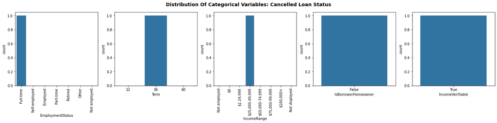

```python
sub_plot(cancelled)
plt.suptitle('Distribution of Categorical Variables: Cancelled Loan Status'.title(), fontsize =14, weight = 'bold')
plt.tight_layout()
```

The chart above is a subplots of variables for the Cancelled LoanStatus dataset.

> Only one borrower has the LoanStatus cancelled. This is a Full-time worker that took a loan at 36 Term with an IncomeRange of 25,000 - 49,999, not a HomeOwner, though the Income Verification is True.

#### To find the Occupation type with the highest number of borrowers

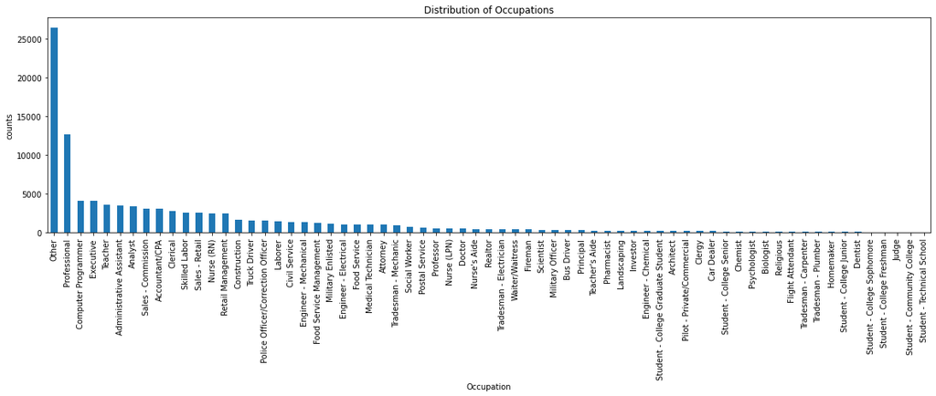

```python
plt.figure(figsize = [20, 5])
loans.Occupation.value_counts().plot(kind = 'bar')
plt.xlabel('Occupation')
plt.ylabel('counts')
plt.title('Distribution of Occupations')
```

The Occupation type of Other has the highest number of borrowers, followed by Professional.

### Discuss the distribution(s) of your variable(s) of interest. Were there any unusual points? Did you need to perform any transformations?

> The linear distribution for the StatedMonthlyIncome couldnt't give a broad distribution. I thereby performed a log transformation of the plot. The resulting plot is a normal distribution. The LoanOriginalAmount distribution plot did not need any transformation. The linear distribution shows several peak values.

### Of the features you investigated, were there any unusual distributions? Did you perform any operations on the data to tidy, adjust, or change the form of the data? If so, why did you do this?

> I removed null rows in BorrowerState, EmploymentStatus columns. There was an outlier in StatedMonthlyIncome column(1750002.916667 instead of 175002.916667). I did all this to avoid wrong analysis of the data set.

## Bivariate Exploration

> In this section, investigate relationships between pairs of variables in your data. Make sure the variables that you cover here have been introduced in some fashion in the previous section (univariate exploration).

#### Defining functions for chart

```python
def violinplot(data, x = 'x', y = ''):
    plt.figure(figsize = [20,5])
    base_color = sb.color_palette()[0]
    return sb.violinplot(data = data, x = x, y = y, color = base_color)

def boxplot(data, x = 'x', y = ''):
    plt.figure(figsize = [20,5])
    base_color = sb.color_palette()[0]
    return sb.boxplot(data = data, x = x, y = y, color = base_color);

def barplot(data, x = 'x', y = '', order = ''):
    plt.figure(figsize = [20,5])
    base_color = sb.color_palette()[0]
    return sb.barplot(data = data, x = x, y = y, color = base_color, order = order);

def bivariate_count(data, x = 'x', hue = 'y'):
    plt.figure(figsize = [20, 5])
    order = loans['LoanStatus'].value_counts().index
    base_color = sb.color_palette()[0]
    plt.xticks(rotation = 45)
    return sb.countplot(data = loans, x= x, hue = hue, order = order);
```

#### To Investigate the relationship between Term and LoanOriginalAmount

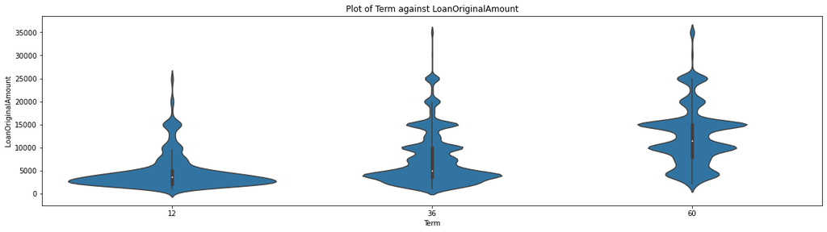

```python
violinplot(loans, 'Term', 'LoanOriginalAmount')
plt.title("Plot of Term against LoanOriginalAmount")
```

The plot above shows the relationship between the Term variable and the LoanOriginalAmount.

> For Term 12, there are several borrowers with LoanOriginalAmount below 5000.

> For the 36 Term, borrowers are more at the region below 5000 LoanOriginalAmount, few between 5000 and 10000, also between 10000 and 15000.

> For the 60 Term, there are more borrowers at the upper region of LoanOriginalAmount. Points between 15000 and 10000 has more borrowers, followed by 10000 and 5000, then below 5000.

#### To Investigate the relationship between LoanStatus and LoanOriginalAmount

```
(array([-5000.,     0.,  5000., 10000., 15000., 20000., 25000., 30000.,
        35000., 40000.]),
 [Text(0, 0, ''),
```

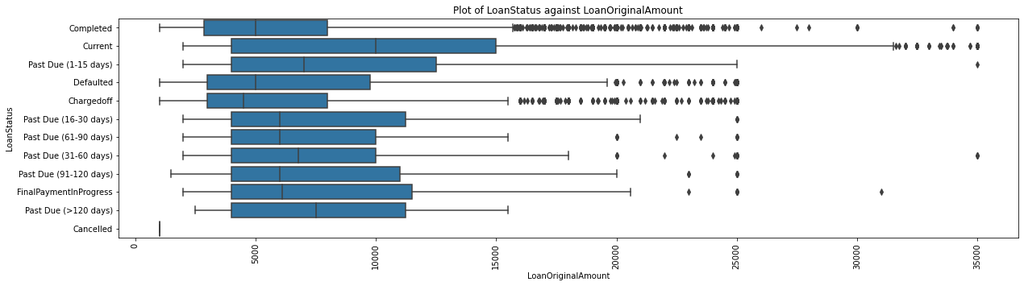

```python
boxplot(loans, 'LoanOriginalAmount', 'LoanStatus' )
plt.title("Plot of LoanStatus against LoanOriginalAmount")
plt.xticks(rotation = 90)
```

The plot above shows the relationship between LoanStatus and LoanOriginalAmount.

> The completed LoanStatus has values of LoanOriginalAmount around 4000 and above but less than 10000.

> Current has vaues around 5000 and above up to 15000.

> Defaulted has values ranging from 4000 but less than 15000.

> Chargedoff has values almost same as the completed LoanStatus.

#### To Investigate the relationship between StatedMonthlyIncome and LoanOriginalAmount

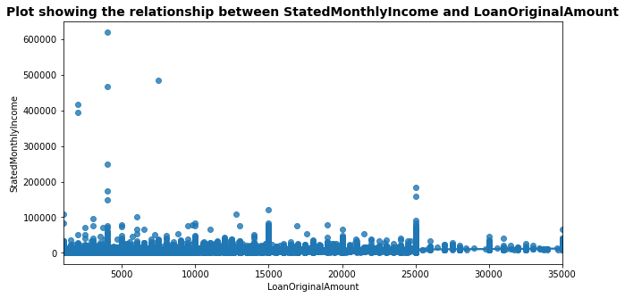

```python
plt.figure(figsize = [10,5])
sb.regplot(data = loans, y = 'StatedMonthlyIncome', x = 'LoanOriginalAmount')
plt.title('Plot showing the relationship between StatedMonthlyIncome and LoanOriginalAmount', fontsize = 14, weight = 'bold')
```

#### To find how the variables relates with one another using a correlation plot

[figure not shown]

```python
plt.figure(figsize = [20,8])
sb.heatmap(loans.corr(), annot = True, cmap = 'viridis_r', center = 0)
plt.title('A correlation plot of all variables', fontsize = 10, weight = 'bold');
```

#### To Investigate the relationship between LoanStatus and IsBorrowerHomeowner

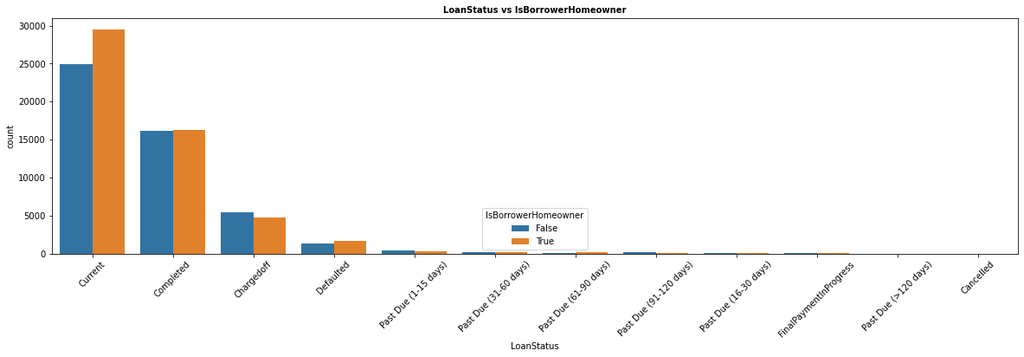

```python
bivariate_count(loans, 'LoanStatus', 'IsBorrowerHomeowner')
plt.title('LoanStatus vs IsBorrowerHomeowner', fontsize = 10, weight = 'bold');
```

#### To Investigate the relationship between LoanStatus and IncomeVerifiable

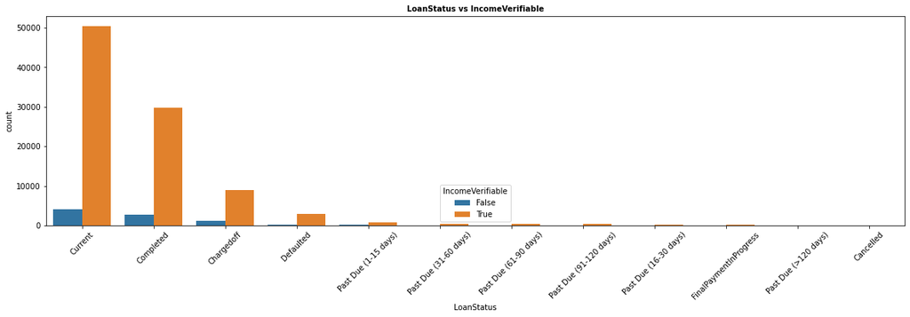

```python
bivariate_count(loans, 'LoanStatus', 'IncomeVerifiable')
plt.title('LoanStatus vs IncomeVerifiable', fontsize = 10, weight = 'bold')
```

The plot above gives a clear presentation of the LoanStatus of borrowers to 'IncomeVerifiable'. The IncomeVerifiable status of True has more count for all category of LoanStatus.

#### To Investigate the relationship between LoanStatus and Term

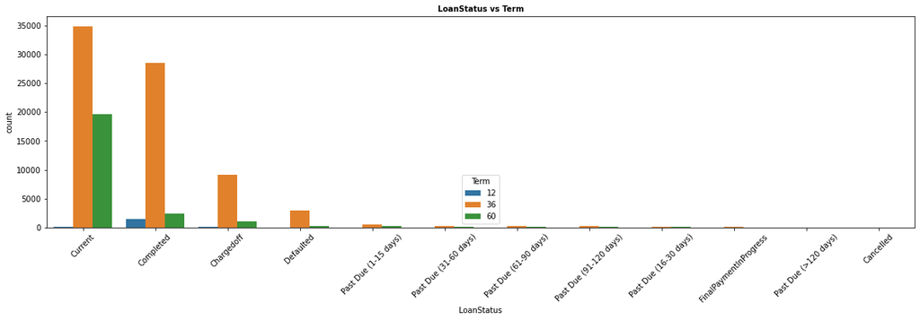

```python
bivariate_count(loans, 'LoanStatus', 'Term')
plt.title('LoanStatus vs Term', fontsize = 10, weight = 'bold')
```

There are more Terms of 36 for all the categories of the LoanStatus, followed by Term 60.

#### To Investigate the relationship between BorrowerState and IsBorrowerHomeowner

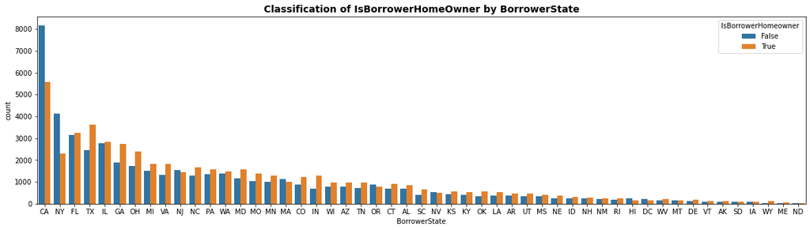

```python
plt.figure(figsize = [20,5])
order = loans['BorrowerState'].value_counts().index
sb.countplot(data = loans, x = 'BorrowerState', hue = 'IsBorrowerHomeowner', order = order)
plt.title('Classification of IsBorrowerHomeOwner by BorrowerState', fontsize = 14, weight = 'bold')
```

The plot above is a classification of the BorrowerState and owning a home. States like 'CA' and 'NY' which have the highest number of borrowers, also has the highest number of borrowers who do not own a home. It is observed that as the state number of borrower reduces, there are more borrowers who own a home.

#### To Investigate the relationship between LoanOriginalAmount and IncomeRange

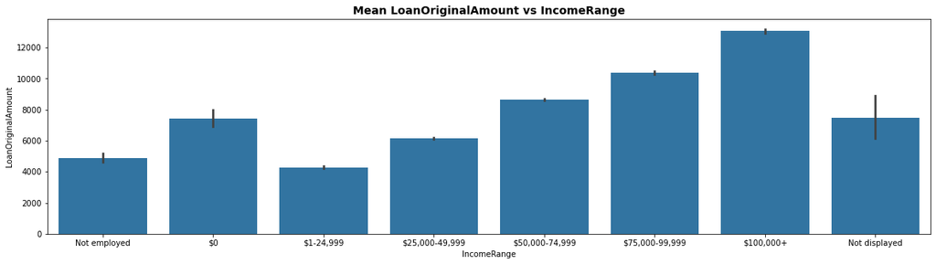

```python
barplot(loans, 'IncomeRange', 'LoanOriginalAmount', order = income_order);
plt.title('Mean LoanOriginalAmount vs IncomeRange', fontsize = 14, weight = 'bold')
```

### Talk about some of the relationships you observed in this part of the investigation. How did the feature(s) of interest vary with other features in the dataset?

> LoanStatus:There is considerable variation between LoanStatus and the categories in the 'IsBorrowerHomeowner', 'IncomeVarifiable', 'Term' variables. There exist a relationship between LoanStatus and LoanOriginalAmount.

### Did you observe any interesting relationships between the other features (not the main feature(s) of interest)?

> There exists a relationship between the BorrowerState and IsBorrowerHomeowner. The two top States with highest borrowers has high number of borrowers who do not own a home. While the borrowers in the states with few borrowers has a higher number of home owners.

## Multivariate Exploration

> Create plots of three or more variables to investigate your data even further. Make sure that your investigations are justified, and follow from your work in the previous sections.

#### To Investigate the relationship between Term, LoanOriginalAmount and StatedMonthlyIncome

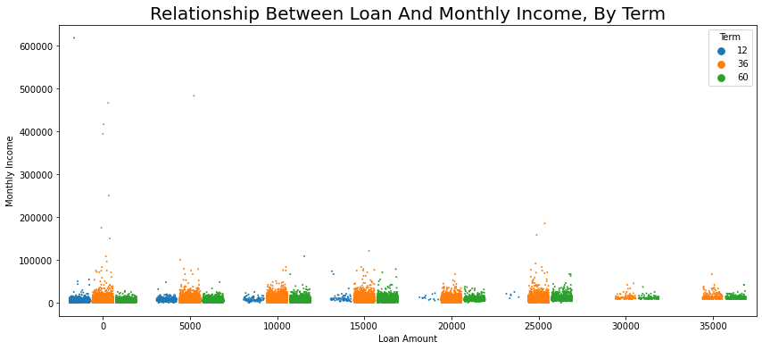

```python
#create loan intervals (say 5k?) using floor division (lowest integer divisor)

loans['LoanOriginalAmount_cat'] = ((loans["LoanOriginalAmount"]//5000)*5000)

f,g= plt.subplots(figsize=[14, 6])

g = sb.stripplot(data=loans, x= 'LoanOriginalAmount_cat', y= 'StatedMonthlyIncome', hue = 'Term',
                 jitter = 0.35, dodge=True, size=2)

plt.title('Relationship between loan and monthly income, by term'.title(), fontsize=20)

plt.xlabel('Loan Amount', fontsize=10);

plt.ylabel('Monthly Income', fontsize=10);
```

### Talk about some of the relationships you observed in this part of the investigation. Were there features that strengthened each other in terms of looking at your feature(s) of interest?

> In this part of the investigation, I observed the relationship between StatedMonthlyIncome, LoanOriginalAmount and Term. The Term variable strengthened the distribution of the other two variables. It clearly gave an insight on the range of values for LoanOriginalAmount and StatedMonthlyIncome for the different Terms.